# Slingshot: Lineage Inference for Single-cell Data

Kelly Street

2018-05-29

# 1 Introduction

This vignette will demonstrate a full single-cell lineage analysis workflow, with particular emphasis on the processes of lineage reconstruction and pseudotime inference. We will make use of the `slingshot` package proposed in (Street et al. 2017) and show how it may be applied in a broad range of settings.

The goal of `slingshot` is to use clusters of cells to uncover global structure and convert this structure into smooth lineages represented by one-dimensional variables, called “pseudotime.” We provide tools for learning cluster relationships in an unsupervised or semi-supervised manner and constructing smooth curves representing each lineage, along with visualization methods for each step.

## 1.1 Overview

The minimal input to `slingshot` is a matrix representing the cells in a reduced-dimensional space and a vector of cluster labels. With these two inputs, we then:

- Identify the global lineage structure by constructing an minimum spanning tree (MST) on the clusters, with the `getLineages` function.
- Construct smooth lineages and infer pseudotime variables by fitting simultaneous principal curves with the `getCurves` function.
- Assess the output of each step with built-in visualization tools.

## 1.2 Datasets

We will work with two simulated datasets in this vignette. The first was generated by the `splatter` package (Zappia, Phipson, and Oshlack 2017), using parameters inferred from the single-cell dataset contained in the `HSMMSingleCell` package. This dataset is contained in a `SingleCellExperiment` object (Lun and Risso 2017) and will be used to demonstrate a full “start-to-finish” workflow. It can be loaded via the `splatterPath` dataset, provided with `slingshot`. Below, we provide code showing how the dataset was generated.

```r
library(HSMMSingleCell, quietly = TRUE)
library(splatter, quietly = TRUE)

# load data
data("HSMM_expr_matrix")
counts <- round(HSMM_expr_matrix)

# estimate simulation parameters
params <- splatEstimate(counts)

# set path-related parameters
params <- setParams(params, update = list(batchCells = 200,
                                          path.nonlinearProb = .5,
                                          de.prob = .6, de.facLoc = 1,
                                          de.facScale = 2))
```

```r
# simulate
sim <- splatSimulate(params, method = "paths")
```

```
## Getting parameters...
```

```
## Creating simulation object...
```

```
## Simulating library sizes...
```

```
## Simulating gene means...
```

```
## Simulating path endpoints...
```

```
## Simulating path steps...
```

```
## Simulating BCV...
```

```
## Simulating counts..
```

```
## Simulating dropout (if needed)...
```

```
## Done!
```

The second dataset consists of a $140$ cells $\times$ $2$ dimensions matrix of coordinates, along with cluster labels generated by $k$-means clustering. This dataset represents a bifurcating lineage trajectory and it will allow us to demonstrate some of the additional functionality offered by `slingshot`.

```r
library(slingshot, quietly = FALSE)
data("slingshotExample")

dim(rd) # data representing cells in a reduced dimensional space
```

```
## [1] 140   2
```

```r
length(cl) # vector of cluster labels
```

```
## [1] 140
```

# 2 Upstream Analysis

## 2.1 Gene Filtering

To begin our analysis of the single lineage dataset, we need to reduce the dimensionality of our data and filtering out uninformative genes is a typical first step. This will greatly improve the speed of downstream analyses, while keeping the loss of information to a minimum.

```r
# filter genes down to potential cell-type markers
# at least M (15) reads in at least N (15) cells
geneFilter <- apply(assays(sim)$counts,1,function(x){
    sum(x >= 15) >= 15
})
sim <- sim[geneFilter, ]
```

## 2.2 Normalization

Another important early step in most RNA-Seq analysis pipelines is the choice of normalization method. This allows us to remove unwanted technical or biological artifacts from the data, such as batch, sequencing depth, cell cycle effects, etc. In practice, it is valuable to compare a variety of normalization techniques and compare them along different evaluation criteria, for which we recommend the `scone` package (Cole and Risso 2018).

Since we are working with simulated data, we have the advantage of knowing what effects are present. In this case, we know that each simulated cell had a unique expected library size and we will apply quantile normalization in order to remove this effect.

```r
FQnorm <- function(counts){
  rk <- apply(counts,2,rank,ties.method='min')
  counts.sort <- apply(counts,2,sort)
  refdist <- apply(counts.sort,1,median)
  norm <- apply(rk,2,function(r){ refdist[r] })
  rownames(norm) <- rownames(counts)
  return(norm)
}
assays(sim)$norm <- FQnorm(assays(sim)$counts)
```

## 2.3 Dimensionality Reduction

The fundamental assumption of `slingshot` is that cells which are transcriptionally similar will be close to each other in some reduced-dimensional space. Since we use Euclidean distances in constructing lineages and measuring pseudotime, it is important to have a low-dimensional representation of the data.

There are many methods available for this task and we will intentionally avoid the issue of determining which is the “best” method, as this likely depends on the type of data, method of collection, upstream computational choices, and many other factors. We will demonstrate two methods of dimensionality reduction: principal components analysis (PCA) and diffusion maps (via the `destiny` package, (Angerer et al. 2015)).

When performing PCA, we do not scale the genes by their variance because we do not believe that all genes are equally informative. We want to find signal in the robustly expressed, highly variable genes, not dampen this signal by forcing equal variance across genes. When plotting, we make sure to set the aspect ratio, so as not to distort the perceived distances.

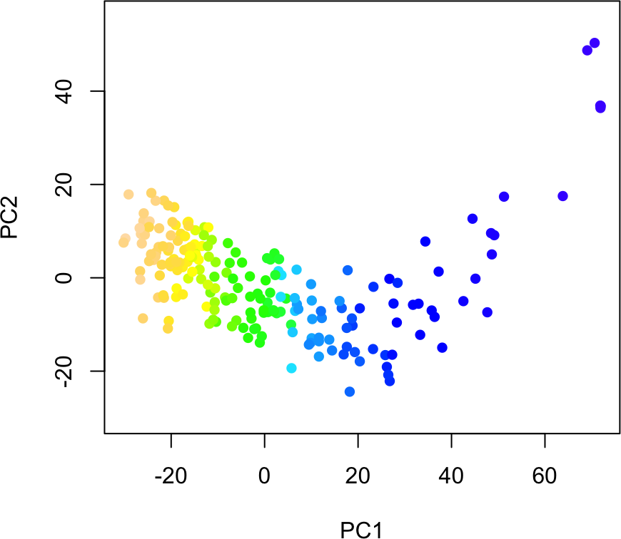

```r
pca <- prcomp(t(log1p(assays(sim)$norm)), scale. = FALSE)
rd1 <- pca$x[,1:2]

plot(rd1, col = topo.colors(100)[sim$Step], pch=16, asp = 1)
```

```r
library(destiny, quietly = TRUE)
```

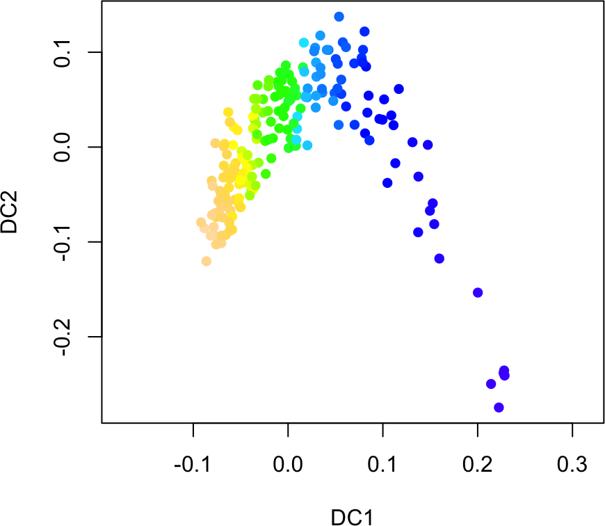

```r
dm <- DiffusionMap(t(log1p(assays(sim)$norm)))
rd2 <- cbind(DC1 = dm$DC1, DC2 = dm$DC2)

plot(rd2, col = topo.colors(100)[sim$Step], pch=16, asp = 1)
```

We will add both dimensionality reductions to the `SingleCellExperiment` object, but continue our analysis focusing on the PCA results.

```r
reducedDims(sim) <- SimpleList(PCA = rd1, DiffMap = rd2)
```

## 2.4 Clustering Cells

The final input to `slingshot` is a vector of cluster labels for the cells. If this is not provided, `slingshot` will treat the data as a single cluster and fit a standard principal curve. However, we recommend clustering the cells even in datasets where only a single lineage is expected, as it allows for the potential discovery of novel branching events.

The clusters identified in this step will be used to determine the global structure of the underlying lineages (that is, their number, when they branch off from one another, and the approximate locations of those branching events). This is different than the typical goal of clustering single-cell data, which is to identify all biologically relevant cell types present in the dataset. For example, when determining global lineage structure, there is no need to distinguish between immature and mature neurons since both cell types will, presumably, fall along the same segment of a lineage.

For our analysis, we implement two clustering methods which similarly assume that Euclidean distance in a low-dimensional space reflect biological differences between cells: Gaussian mixture modeling and $k$-means. The former is implemented in the `mclust` package (Scrucca et al. 2016) and features an automated method for determining the number of clusters based on the Bayesian information criterion (BIC).

```r
library(mclust, quietly = TRUE)
cl1 <- Mclust(rd1)$classification
```

```
## fitting ...
##
```

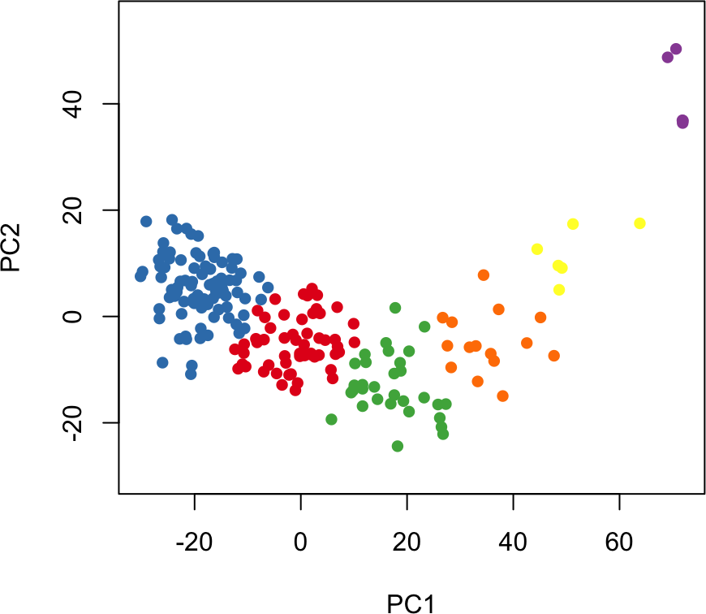

```r
colData(sim)$GMM <- cl1

library(RColorBrewer)
plot(rd1, col = brewer.pal(9,"Set1")[cl1], pch=16, asp = 1)
```

While $k$-means does not have a similar functionality, we have shown in (Street et al. 2017) that simultaneous principal curves are quite robust to the choice of $k$, so we select a $k$ of 4 somewhat arbitrarily. If this is too low, we may miss a true branching event and if it is too high or there is an abundance of small clusters, we may begin to see spurious branching events.

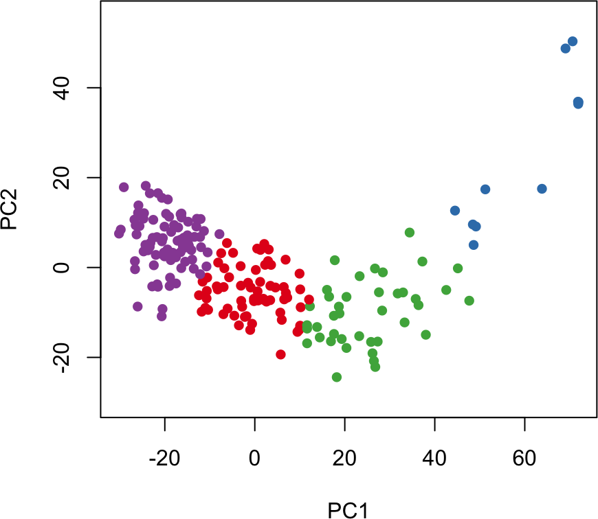

```r
cl2 <- kmeans(rd1, centers = 4)$cluster
colData(sim)$kmeans <- cl2

plot(rd1, col = brewer.pal(9,"Set1")[cl2], pch=16, asp = 1)
```

# 3 Using Slingshot

At this point, we have everything we need to run `slingshot` on our simulated dataset. This is a two-step process composed of identifying the global lineage structure with a cluster-based minimum spanning tree (MST) and fitting simultaneous principal curves to describe each lineage.

These two steps can be run separately with the `getLineages` and `getCurves` functions, or together with the wrapper function, `slingshot` (recommended). We will use the combined method for the analysis of the `splatter` dataset, but demonstrate the usage of the individual functions later, on the `slingshot` dataset.

The `slingshot` wrapper function performs both steps of lineage inference in a single call. The necessary inputs are a reduced dimensional matrix of coordinates and a set of cluster labels. These can be separate objects or, in the case of the `splatter` data, elements contained in a `SingleCellExperiment` object.

To run `slingshot` with the dimensionality reduction produced by PCA and cluster labels identified by Gaussian mixutre modeling, we would do the following:

```r
sce <- slingshot(sim, clusterLabels = 'GMM', reducedDim = 'PCA')
```

```
## Using full covariance matrix
```

As noted above, if no clustering results are provided, it is assumed that all cells are part of the same cluster and a single curve will be constructed. If no dimensionality reduction is provided, `slingshot` will use the first element of the list returned by `reducedDims`.

The output is a `SingleCellExperiment` object with `slingshot` results incorporated. Most of the output is added to the metadata in the form of a list and is accessible via `metadata(sce)$slingshot`. Additionally, all inferred pseudotime variables (one per lineage) are added to the `colData`. To extract all `slingshot` results in a single object, we can use the `SlingshotDataSet` function. This can be useful for visualization, as several plotting methods for `SlingshotDataSet` objects are included with the package. Below, we visuzalize the inferred lineage for the `splatter` data with points colored by pseudotime.

```r
summary(sce$slingPseudotime_1)
```

```
##    Min. 1st Qu.  Median    Mean 3rd Qu.    Max.
##    0.00   17.87   31.35   37.98   51.01  143.27
```

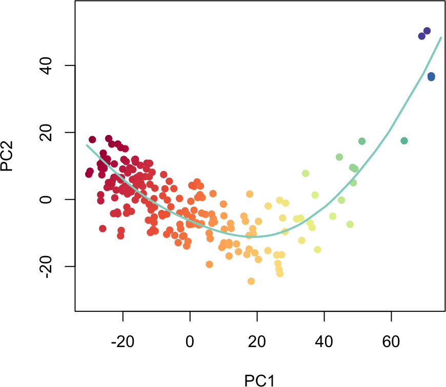

```r
colors <- colorRampPalette(brewer.pal(11,'Spectral')[-6])(100)
plot(reducedDims(sce)$PCA, col = colors[cut(sce$slingPseudotime_1,breaks=100)], pch=16, asp = 1)
lines(SlingshotDataSet(sce), lwd=2)
```

We can also see how the lineage structure was intially estimated by the cluster-based minimum spanning tree by using the `type` argument.

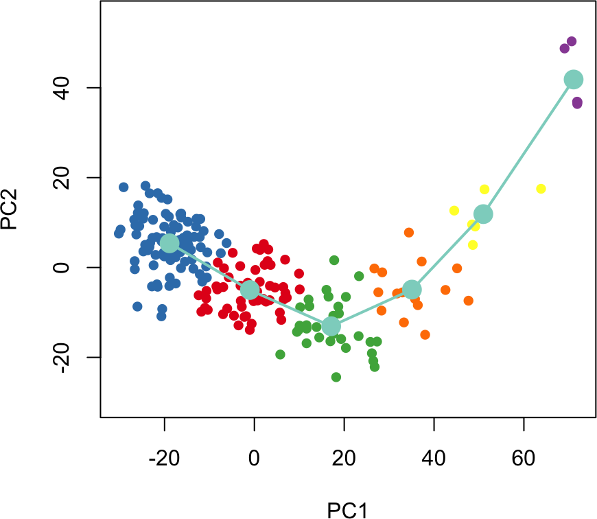

```r
plot(reducedDims(sce)$PCA, col = brewer.pal(9,'Set1')[sce$GMM], pch=16, asp = 1)
lines(SlingshotDataSet(sce), lwd=2, type = 'lineages')
```

# 4 Downstream Analysis

## 4.1 Identifying temporally expressed genes

After running `slingshot`, an interesting next step may be to find genes that change their expression over the course of development. We demonstrate one possible method for this type of analysis on the $1,000$ most variable genes.

We will regress each gene on the pseudotime variable we have generated, using a general additive model (GAM). This allows us to detect non-linear patterns in gene expression.

```r
require(gam)
t <- sce$slingPseudotime_1

# for time, only look at the 1,000 most variable genes
Y <- log1p(assays(sim)$norm)
var1K <- names(sort(apply(Y,1,var),decreasing = TRUE))[1:1000]
Y <- Y[var1K,]

# fit a GAM with a loess term for pseudotime
gam.pval <- apply(Y,1,function(z){
  d <- data.frame(z=z, t=t)
  tmp <- gam(z ~ lo(t), data=d)
  p <- summary(tmp)[4][[1]][1,5]
  p
})
```

We can then pick out the top genes based on p-value and visualize their expression over developmental time with a heatmap.

```r
require(clusterExperiment)
```

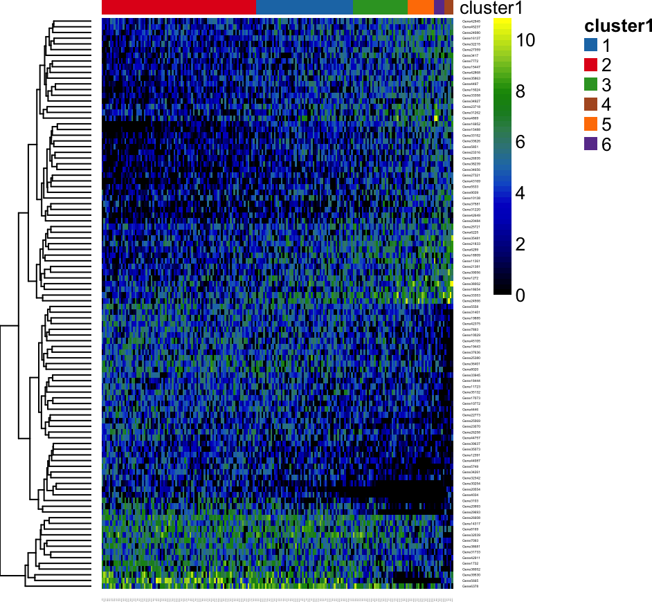

```r
topgenes <- names(sort(gam.pval, decreasing = FALSE))[1:100]
heatdata <- assays(sim)$norm[rownames(assays(sim)$norm) %in% topgenes,
                        order(t, na.last = NA)]
heatclus <- sce$GMM[order(t, na.last = NA)]
ce <- ClusterExperiment(heatdata, heatclus, transformation = log1p)
plotHeatmap(ce, clusterSamplesData = "orderSamplesValue",visualizeData = 'transformed')
```

# 5 Detailed Slingshot Functionality

Here, we provide further details and highlight some additional functionality of the `slingshot` package. We will use the included `slingshotExample` dataset for illustrative purposes. This dataset was designed to represent cells in a low dimensional space and comes with a set of cluster labels generated by $k$-means clustering. Rather than constructing a full `SingleCellExperiment` object, which requires gene-level data, we will use the low-dimensional matrix of coordinates directly and provide the cluster labels as an additional argument.

## 5.1 Identifying global lineage structure

The `getLineages` function takes as input an `n` $\times$ `p` matrix and a vector of clustering results of length `n`. It maps connections between adjacent clusters using a minimum spanning tree (MST) and identifies paths through these connections that represent lineages. The output of this function is a `SlingshotDataSet` containing the inputs as well as the inferred MST (represented by an adjacency matrix) and lineages (ordered vectors of cluster names).

This analysis can be performed in an entirely unsupervised manner or in a semi-supervised manner by specifying known initial and terminal point clusters. If we do not specify a starting point, `slingshot` selects one based on parsimony, maximizing the number of clusters shared between lineages before a split. If there are no splits or multiple clusters produce the same parsimony score, the starting cluster is chosen arbitrarily.

In the case of our simulated data, `slingshot` selects Cluster 1 as the starting cluster. However, we generally recommend the specification of an initial cluster based on prior knowledge (either time of sample collection or established gene markers). This specification will have no effect on how the MST is constructed, but it will impact how branching curves are constructed.

```r
lin1 <- getLineages(rd, cl, start.clus = '1')
```

```
## Using full covariance matrix
```

```r
lin1
```

```
## class: SlingshotDataSet
##
##  Samples Dimensions
##      140          2
##
## lineages: 2
## Lineage1: 1  2  3  5
## Lineage2: 1  2  3  4
##
## curves: 0
```

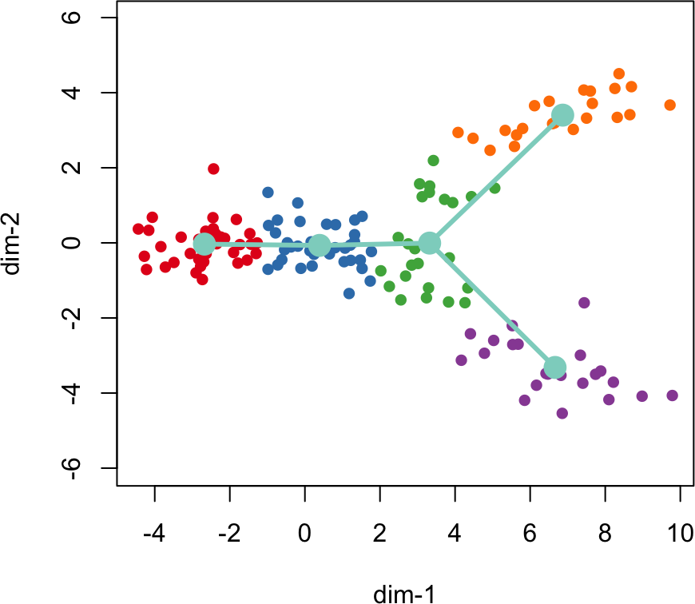

```r
plot(rd, col = brewer.pal(9,"Set1")[cl], asp = 1, pch = 16)
lines(lin1, lwd = 3)
```

At this step, `slingshot` also allows for the specification of known endpoints. Clusters which are specified as terminal cell states will be constrained to have only one connection when the MST is constructed (ie., they must be leaf nodes). This constraint could potentially impact how other parts of the tree are drawn, as shown in the next example where we specify Cluster 3 as an endpoint.

```r
lin2 <- getLineages(rd, cl, start.clus= '1', end.clus = '3')
```

```
## Using full covariance matrix
```

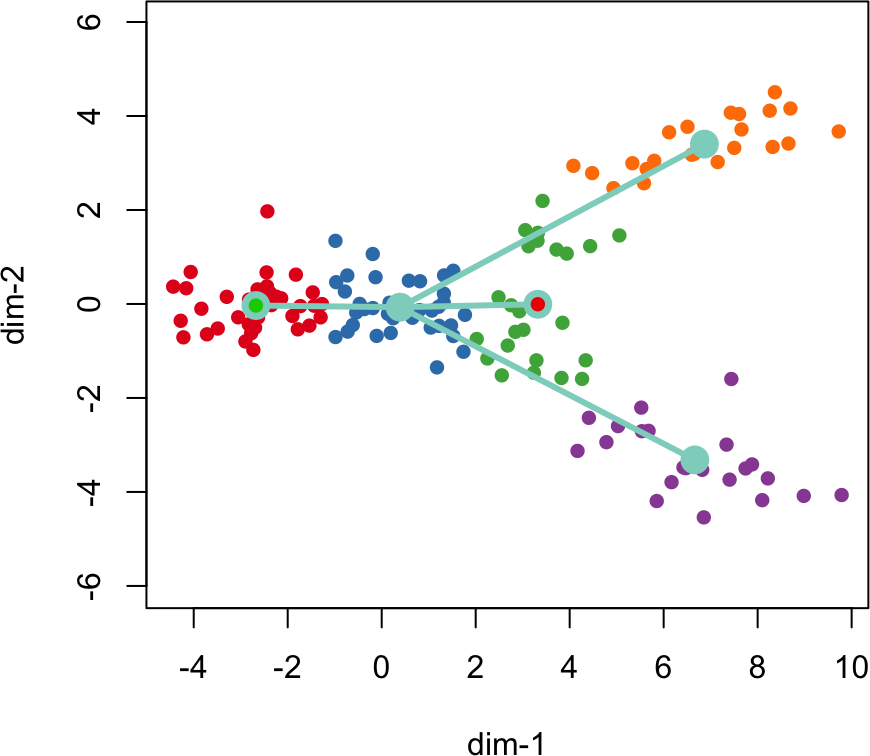

```r
plot(rd, col = brewer.pal(9,"Set1")[cl], asp = 1, pch = 16)
lines(lin2, lwd = 3, show.constraints = TRUE)
```

This type of supervision can be useful for ensuring that results are consistent with prior biological knowledge. Specifically, it can prevent known terminal cell fates from being categorized as transitory states.

There are a few additional arguments we could have passed to `getLineages` for greater control:

- `dist.fun` is a function for computing distances between clusters. The default is squared distance between cluster centers normalized by their joint covariance matrix.
- `omega` is a granularity parameter, allowing the user to set an upper limit on connection distances. This can be useful for identifying outlier clusters which are not a part of any lineage.

After constructing the MST, `getLineages` identifies paths through the tree to designate as lineages. At this stage, a lineage will consist of an ordered set of cluster names, starting with the root cluster and ending with a leaf. The output of `getLineages` is a `SlingshotDataSet` which holds all of the inputs as well as a list of lineages and some additional information on how they were constructed. This object is then used as the input to the `getCurves` function.

## 5.2 Constructing smooth curves and ordering cells

In order to model development along these various lineages, we will construct smooth curves with the function `getCurves`. Using smooth curves based on all the cells eliminates the problem of cells projecting onto vertices of piece-wise linear trajectories and makes `slingshot` more robust to noise in the clustering results.

In order to construct smooth lineages, `getCurves` follows an iterative process similar to that of principal curves presented in (Hastie and Stuetzle 1989). When there is only a single lineage, the resulting curve is simply the principal curve through the center of the data, with one adjustment: the initial curve is constructed with the linear connections between cluster centers rather than the first prinicpal component of the data. This adjustment adds stability and typically hastens the algorithm’s convergence.

When there are two or more lineages, we add an additional step to the algorithm: averaging curves near shared cells. Both lineages should agree fairly well on cells that have yet to differentiate, so at each iteration we average the curves in the neighborhood of these cells. This increases the stability of the algorithm and produces smooth branching lineages.

```r
crv1 <- getCurves(lin1)
crv1
```

```
## class: SlingshotDataSet
##
##  Samples Dimensions
##      140          2
##
## lineages: 2
## Lineage1: 1  2  3  5
## Lineage2: 1  2  3  4
##
## curves: 2
## Curve1: Length: 15.054   Samples: 102.3
## Curve2: Length: 15.118   Samples: 103.12
```

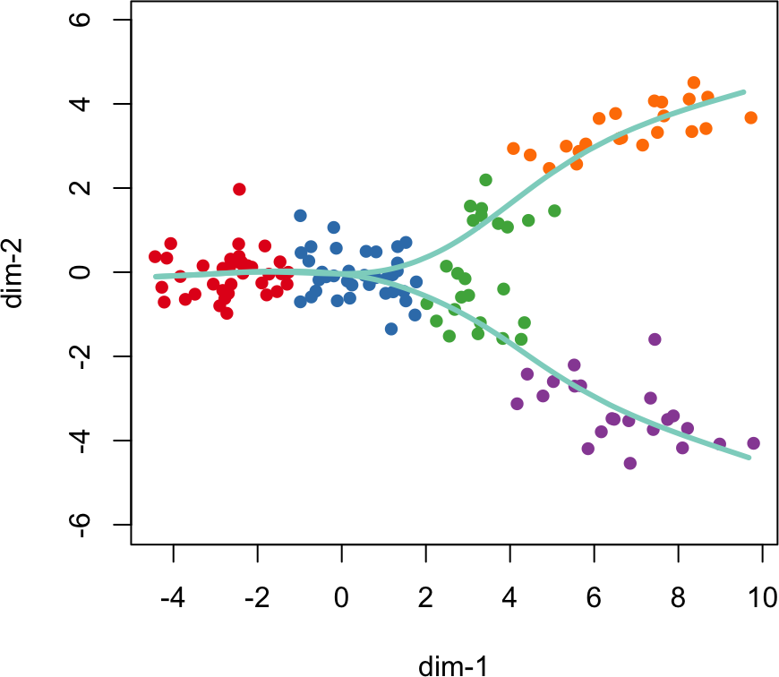

```r
plot(rd, col = brewer.pal(9,"Set1")[cl], asp = 1, pch = 16)
lines(crv1, lwd = 3)
```

The output of `getCurves` is an updated `slingshotDataSet` which now contains the simultaneous principal curves and additional information on how they were fit. The `pseudotime` function extracts a cells-by-lineages matrix of pseudotime values for each cell along each lineage, with `NA` values for cells that were not assigned to a particular lineage. The `curveWeights` function extracts a similar matrix of weights assigning each cell to one or more lineages.

The curves objects can be accessed using the `curves` function, which will return a list of `principal.curve` objects. These objects consist of the following slots:

- `s`: the matrix of points that make up the curve. These correspond to the orthogonal projections of the data points.
- `tag`: indices which can be used to put the cells along a curve in order based their projections.
- `lambda`: arclengths along the curve from the beginning to each cell’s projection. A matrix of these values is returned by the `slingPseudotime` function.
- `dist`: the squared distances between data points and their projections onto the curve.
- `w`: the vector of weights along this lineage. Cells that were unambiguously assigned to this lineage will have a weight of `1`, while cells assigned to other lineages will have a weight of `0`. It is possible for cells to have weights of `1` (or very close to 1) for multiple lineages, if they are positioned before a branching event. A matrix of these values is returned by the `slingCurveWeights` function.

# References

Angerer, Philipp, Laleh Haghverdi, Maren Büttner, Fabian Theis, Carsten Marr, and Florian Büttner. 2015. “Destiny: Diffusion Maps for Large-Scale Single-Cell Data in R.” *Bioinformatics* 32 (8). Ingolstädter Landstraße 1, Neuherberg, Germany: Helmholtz-Zentrum München: 1241. doi:10.1093/bioinformatics/btv715.

Cole, Michael, and Davide Risso. 2018. *Scone: Single Cell Overview of Normalized Expression Data*.

Hastie, Trevor, and Werner Stuetzle. 1989. “Principal Curves.” *Journal of the American Statistical Association* 84 (406): 502–16.

Lun, Aaron, and Davide Risso. 2017. *SingleCellExperiment: S4 Classes for Single Cell Data*.

Scrucca, Luca, Michael Fop, Thomas Brendan Murphy, and Adrian E. Raftery. 2016. “mclust 5: Clustering, Classification and Density Estimation Using Gaussian Finite Mixture Models.” *The R Journal* 8 (1): 205–33.

Street, Kelly, Davide Risso, Russell B Fletcher, Diya Das, John Ngai, Nir Yosef, Elizabeth Purdom, and Sandrine Dudoit. 2017. “Slingshot: Cell Lineage and Pseudotime Inference for Single-Cell Transcriptomics.” *BioRxiv*. Cold Spring Harbor Laboratory. doi:10.1101/128843.

Zappia, Luke, Belinda Phipson, and Alicia Oshlack. 2017. “Splatter: Simulation of Single-Cell RNA Sequencing Data.” *Genome Biology* 18 (September): 174. doi:10.1186/s13059-017-1305-0.